# Coursera Reproduciable Research Project 1

## Introduction

This assignment makes use of data from a personal activity monitoring device. This device collects data at 5 minute intervals through out the day. The data consists of two months of data from an anonymous individual collected during the months of October and November, 2012 and include the number of steps taken in 5 minute intervals each day.

The data for this assignment can be downloaded from the course web site:

Dataset: Activity monitoring data [52K]

The dataset is stored in a comma-separated-value (CSV) file and there are a total of 17,568 observations.

Variables included in this dataset are:

**steps:** Number of steps taking in a 5-minute interval (missing values are coded as NA).

**date:** The date on which the measurement was taken in YYYY-MM-DD format.

**interval:** Identifier for the 5-minute interval in which measurement was taken

## Assignment

This assignment involves creating an R markdown document that can be processed with Knitr to be displayed in HTML format. The document will answer question about the Activity monitoring data by loading and processing data. the document will contains the answers to the questions and also the code used to load the data.

## Q1. Loading and preprocessing the data

Load the data

```r
activity <- read.csv("activity.csv", header = TRUE)
```

Format date column to date type and save as a data frame.

```r
activity$date <- as.Date(activity$date, "%Y-%m-%d")
activity <- as.data.frame(activity)
```

## Q2. What is mean total number of steps taken per day?

Calculate the total number of steps taken per day (Ignore missing values).

```r
stepsperday <- tapply(activity$steps, activity$date, sum)
```

Make a histogram of the frequency of total number of steps per day

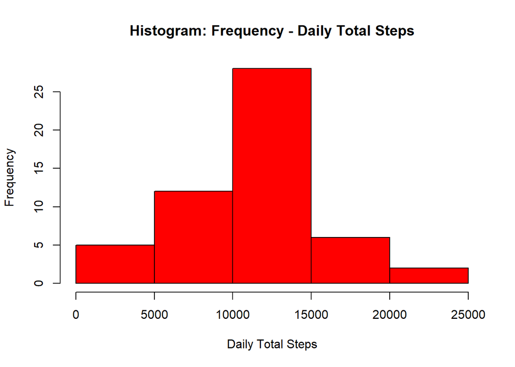

```r
hist(stepsperday,
     col = "red",
     xlab = "Daily Total Steps",
     ylab = "Frequency ",
     main = "Histogram: Frequency - Daily Total Steps")
```

```r
meansteps <- mean(stepsperday, na.rm = TRUE)
mediansteps <- median(stepsperday, na.rm = TRUE)
```

## Q3. What is the average daily activity pattern?

Make a time series plot (i.e. type = “l”) of the 5-minute interval (x-axis) and the average number of steps taken, averaged across all days (y-axis)

Average number of steps taken per interval

```r
avgstepsinterval <- tapply(activity$steps, activity$interval, mean, na.rm = TRUE)
```

Time series plot of the average number of steps taken

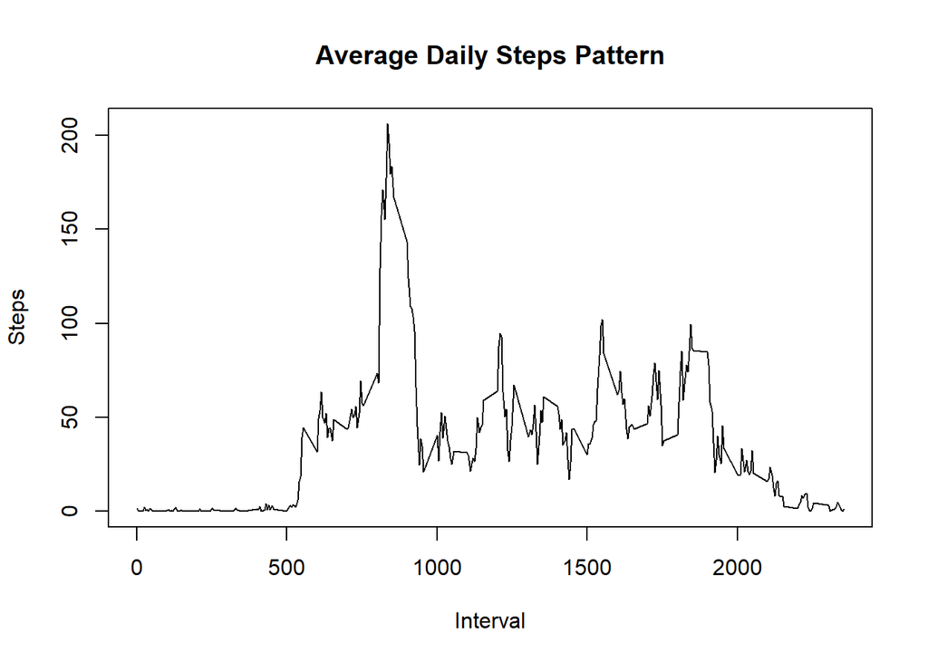

```r
plot(as.numeric(names(avgstepsinterval)),
     avgstepsinterval,
     xlab = "Interval",
     ylab = "Steps",
     main = "Average Daily Steps Pattern",
     type = "l")
```

Which 5-minute interval, on average across all the days in the dataset, contains the maximum number of steps?

```r
maxavgInterval <- names(sort(avgstepsinterval, decreasing = TRUE)[1])
maxavgSteps <- sort(avgstepsinterval, decreasing = TRUE)[1]
```

The 5-minuter interval at 835 contains the maximum number of steps at 206.1698113.